# 615 Shiny

Zhenwei Weng

2024-11-15

1. In Hadley Wickham’s Shiny example, the Hadley_1 version retrieves data directly in each output function, which is less efficient. In contrast, Hadley_2 uses a reactive expression dataset <- reactive({ get(input$dataset, “package:datasets”) }) to optimize the code. It retrieves data only once when needed and caches the result to enhance response speed and application performance. This improvement reduces code duplication, simplifies the application structure, and improves maintenance efficiency.

2.3.5

1. verbatimTextOutput()
2. textOutput()
3. verbatimTextOutput()
4. textOutput()

```r
library(shiny)
ui <- fluidPage(
  titlePanel("Scatterplot of Random Numbers"),
  mainPanel(
    tags$div(
      role = "img",  # Define the role as an image for accessibility
      `aria-label` = "A scatterplot of five random points with x and y coordinates drawn from a uniform distribution.",
      plotOutput(
        outputId = "scatterplot",
        height = "300px",
        width = "700px"
      )
    )
  )
)

server <- function(input, output) {
  output$scatterplot <- renderPlot({
    set.seed(123)  # Set seed for reproducibility
    x <- runif(5)
    y <- runif(5)
    plot(x, y, main = "Scatterplot of Random Numbers", xlab = "X-axis", ylab = "Y-axis", pch = 19, col = "blue")
  })
}

shinyApp(ui = ui, server = server)
```

Shiny applications not supported in static R Markdown documents

```r
library(shiny)
library(DT)
ui <- fluidPage(
  DTOutput("table")
)

server <- function(input, output, session) {
  output$table <- renderDT(
    mtcars,
    options = list(
      searching = FALSE,
      ordering = FALSE,
      paging = FALSE,
      info = FALSE
    )
  )
}

shinyApp(ui = ui, server = server)
```

Shiny applications not supported in static R Markdown documents

```r
library(reactable)

ui <- fluidPage(
  reactableOutput("table")
)

server <- function(input, output, session) {
  output$table <- renderReactable({
    reactable(
      mtcars,
      pagination = TRUE,          # Enable pagination
      searchable = FALSE,         # Disable the search box
      sortable = FALSE,           # Disable column sorting
      showPageSizeOptions = FALSE # Disable option to change number of rows displayed
    )
  })
}

shinyApp(ui, server)
```

Shiny applications not supported in static R Markdown documents

3.3.6 1.

```r
server1 <- function(input, output, session) {  # Corrected argument "server" to "session"
  output$greeting <- renderText({             # Use renderText to assign output
    paste0("Hello ", input$name)              # Access the input$name value
  })
}

server2 <- function(input, output, session) {
  output$greeting <- renderText({             # Use renderText for dynamic text
    paste0("Hello ", input$name)
  })
}

server3 <- function(input, output, session) {
  output$greeting <- renderText({             # Correct the spelling and use renderText
    paste0("Hello ", input$name)
  })
}
```

2. Server 1:

input$a → c

input$b → c

c → e

input$d → e

e → output$f

Server 2:

input$x1 → x

input$x2 → x

input$x3 → x

input$y1 → y

input$y2 → y

x → output$z

y → output$z

Server 3:

input$x1 → x

input$x2 → x

input$x3 → x

input$y1 → y

input$y2 → y

x → output$z

y → output$z

Because of naming conflict. Because they are conflict with base R function.

4.8

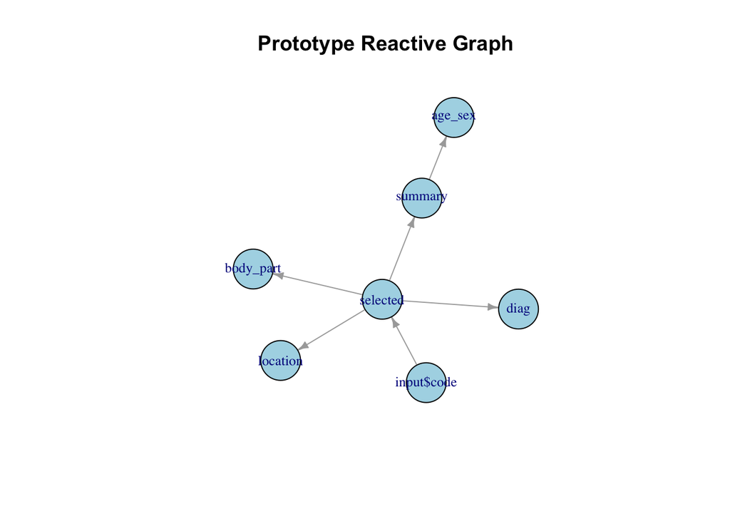

```r
library(igraph)
edges1 <- data.frame(
  from = c("input$code", "selected", "selected", "selected", "selected", "summary"),
  to = c("selected", "diag", "body_part", "location", "summary", "age_sex")
)

# 创建图
graph1 <- graph_from_data_frame(edges1, directed = TRUE)

# 绘制图
plot(graph1, vertex.color = "lightblue", vertex.size = 30, edge.arrow.size = 0.5,
     vertex.label.cex = 0.8, main = "Prototype Reactive Graph")
```

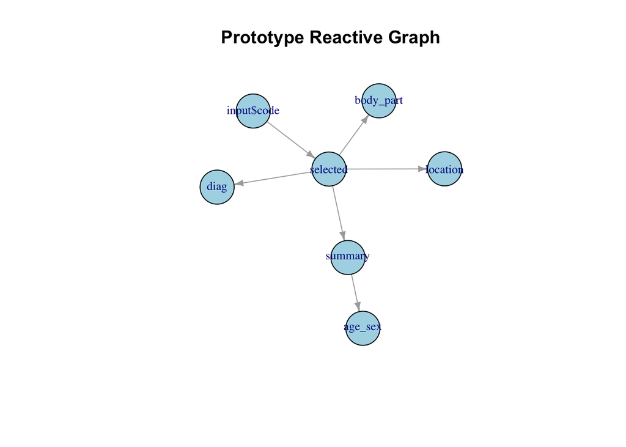

```r
edges2 <- data.frame(
  from = c("input$code", "selected", "selected", "selected", "selected", "summary"),
  to = c("selected", "diag", "body_part", "location", "summary", "age_sex")
)

graph1 <- graph_from_data_frame(edges2, directed = TRUE)
plot(graph1, vertex.color = "lightblue", vertex.size = 30, edge.arrow.size = 0.5,
     vertex.label.cex = 0.8, main = "Prototype Reactive Graph")
```

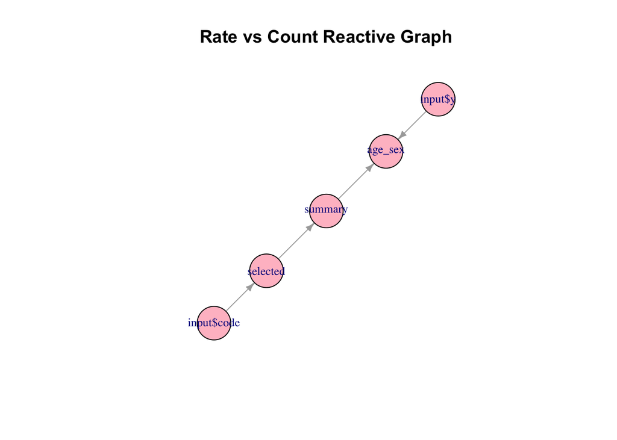

```r
edges3 <- data.frame(
  from = c("input$code", "input$y", "selected", "summary"),
  to = c("selected", "age_sex", "summary", "age_sex")
)

graph3 <- graph_from_data_frame(edges3, directed = TRUE)

plot(graph3, vertex.color = "pink", vertex.size = 30, edge.arrow.size = 0.5,
     vertex.label.cex = 0.8, main = "Rate vs Count Reactive Graph")
```

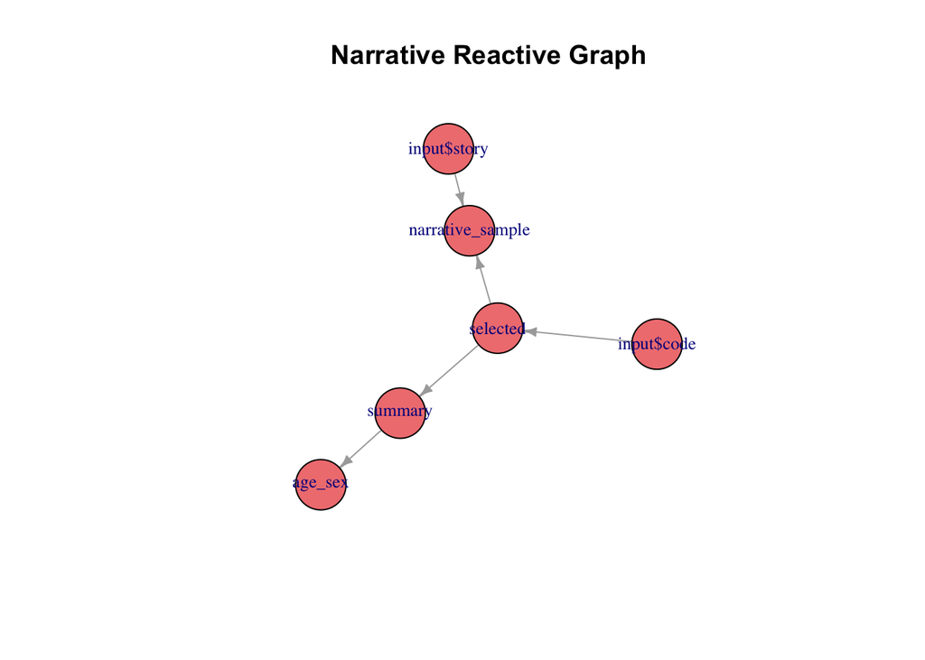

```r
edges4 <- data.frame(
  from = c("input$code", "input$story", "selected", "selected", "summary"),
  to = c("selected", "narrative_sample", "narrative_sample", "summary", "age_sex")
)
graph4 <- graph_from_data_frame(edges4, directed = TRUE)
plot(graph4, vertex.color = "lightcoral", vertex.size = 30, edge.arrow.size = 0.5,
     vertex.label.cex = 0.8, main = "Narrative Reactive Graph")
```

2. fct_infreq() first ensures levels are sorted by frequency so that fct_lump() selects the correct top n.Flipping them leads to incorrect lumping and potentially misleading summaries.

Add this in the code:

numericInput(“num_rows”, “Number of rows to display:”, value = 5, min = 1, max = 20)

```r
ui <- fluidPage(
  fluidRow(
    column(2, actionButton("prev_story", "Previous")),
    column(2, actionButton("next_story", "Next")),
    column(8, textOutput("narrative"))
  )
)
server <- function(input, output, session) {
  # Reactive value to keep track of the current index
  current_index <- reactiveVal(1)

  # Extract narratives for the selected product
  selected_narratives <- reactive({
    injuries %>%
      filter(prod_code == input$code) %>%
      pull(narrative)
  })

  # Update index when buttons are clicked
  observeEvent(input$next_story, {
    current_index((current_index() %% length(selected_narratives())) + 1)
  })

  observeEvent(input$prev_story, {
    current_index(ifelse(current_index() == 1, length(selected_narratives()), current_index() - 1))
  })

  # Display the current narrative
  output$narrative <- renderText({
    if (length(selected_narratives()) > 0) {
      selected_narratives()[current_index()]
    } else {
      "No narratives available."
    }
  })
}

shinyApp(ui = ui, server = server)
```

Shiny applications not supported in static R Markdown documents